# Risk Factor Analysis

## Outcome Variable

**Outcome Variable:** wast_rec90d

## Predictor Variables

**Intervention Variable:** cleanck

**Adjustment Set:**

- arm
- sex
- W_mage
- meducyrs
- feducyrs
- hhwealth_quart
- hfoodsec
- W_nrooms
- W_parity
- impfloor
- delta_meducyrs
- delta_feducyrs
- delta_hhwealth_quart
- delta_hfoodsec
- delta_W_nrooms
- delta_W_parity
- delta_impfloor

## Stratifying Variables

The analysis was stratified on these variable(s):

- agecat
- studyid
- country

## Data Summary

| agecat | studyid | country | cleanck | wast_rec90d | n_cell | n |
| --- | --- | --- | --- | --- | --- | --- |
| 0-24 months | ki0047075b-MAL-ED | SOUTH AFRICA | 0 | 0 | 0 | 1 |
| 0-24 months | ki0047075b-MAL-ED | SOUTH AFRICA | 0 | 1 | 0 | 1 |
| 0-24 months | ki0047075b-MAL-ED | SOUTH AFRICA | 1 | 0 | 0 | 1 |
| 0-24 months | ki0047075b-MAL-ED | SOUTH AFRICA | 1 | 1 | 1 | 1 |
| 0-24 months | ki1000108-CMC-V-BCS-2002 | INDIA | 0 | 0 | 82 | 326 |
| 0-24 months | ki1000108-CMC-V-BCS-2002 | INDIA | 0 | 1 | 125 | 326 |
| 0-24 months | ki1000108-CMC-V-BCS-2002 | INDIA | 1 | 0 | 38 | 326 |
| 0-24 months | ki1000108-CMC-V-BCS-2002 | INDIA | 1 | 1 | 81 | 326 |
| 0-24 months | ki1000108-IRC | INDIA | 0 | 0 | 72 | 383 |
| 0-24 months | ki1000108-IRC | INDIA | 0 | 1 | 92 | 383 |
| 0-24 months | ki1000108-IRC | INDIA | 1 | 0 | 84 | 383 |
| 0-24 months | ki1000108-IRC | INDIA | 1 | 1 | 135 | 383 |
| 0-24 months | ki1017093b-PROVIDE | BANGLADESH | 0 | 0 | 38 | 307 |
| 0-24 months | ki1017093b-PROVIDE | BANGLADESH | 0 | 1 | 35 | 307 |
| 0-24 months | ki1017093b-PROVIDE | BANGLADESH | 1 | 0 | 90 | 307 |
| 0-24 months | ki1017093b-PROVIDE | BANGLADESH | 1 | 1 | 144 | 307 |
| 0-24 months | ki1017093c-NIH-Crypto | BANGLADESH | 0 | 0 | 37 | 216 |
| 0-24 months | ki1017093c-NIH-Crypto | BANGLADESH | 0 | 1 | 66 | 216 |
| 0-24 months | ki1017093c-NIH-Crypto | BANGLADESH | 1 | 0 | 44 | 216 |
| 0-24 months | ki1017093c-NIH-Crypto | BANGLADESH | 1 | 1 | 69 | 216 |
| 0-24 months | ki1113344-GMS-Nepal | NEPAL | 0 | 0 | 476 | 1018 |
| 0-24 months | ki1113344-GMS-Nepal | NEPAL | 0 | 1 | 528 | 1018 |
| 0-24 months | ki1113344-GMS-Nepal | NEPAL | 1 | 0 | 8 | 1018 |
| 0-24 months | ki1113344-GMS-Nepal | NEPAL | 1 | 1 | 6 | 1018 |
| 0-6 months | ki0047075b-MAL-ED | SOUTH AFRICA | 0 | 0 | 0 | 1 |
| 0-6 months | ki0047075b-MAL-ED | SOUTH AFRICA | 0 | 1 | 0 | 1 |
| 0-6 months | ki0047075b-MAL-ED | SOUTH AFRICA | 1 | 0 | 0 | 1 |
| 0-6 months | ki0047075b-MAL-ED | SOUTH AFRICA | 1 | 1 | 1 | 1 |
| 0-6 months | ki1000108-CMC-V-BCS-2002 | INDIA | 0 | 0 | 45 | 203 |
| 0-6 months | ki1000108-CMC-V-BCS-2002 | INDIA | 0 | 1 | 79 | 203 |
| 0-6 months | ki1000108-CMC-V-BCS-2002 | INDIA | 1 | 0 | 21 | 203 |
| 0-6 months | ki1000108-CMC-V-BCS-2002 | INDIA | 1 | 1 | 58 | 203 |
| 0-6 months | ki1000108-IRC | INDIA | 0 | 0 | 33 | 232 |
| 0-6 months | ki1000108-IRC | INDIA | 0 | 1 | 65 | 232 |
| 0-6 months | ki1000108-IRC | INDIA | 1 | 0 | 52 | 232 |
| 0-6 months | ki1000108-IRC | INDIA | 1 | 1 | 82 | 232 |
| 0-6 months | ki1017093b-PROVIDE | BANGLADESH | 0 | 0 | 13 | 184 |
| 0-6 months | ki1017093b-PROVIDE | BANGLADESH | 0 | 1 | 28 | 184 |
| 0-6 months | ki1017093b-PROVIDE | BANGLADESH | 1 | 0 | 26 | 184 |
| 0-6 months | ki1017093b-PROVIDE | BANGLADESH | 1 | 1 | 117 | 184 |
| 0-6 months | ki1017093c-NIH-Crypto | BANGLADESH | 0 | 0 | 5 | 139 |
| 0-6 months | ki1017093c-NIH-Crypto | BANGLADESH | 0 | 1 | 65 | 139 |
| 0-6 months | ki1017093c-NIH-Crypto | BANGLADESH | 1 | 0 | 8 | 139 |
| 0-6 months | ki1017093c-NIH-Crypto | BANGLADESH | 1 | 1 | 61 | 139 |
| 0-6 months | ki1113344-GMS-Nepal | NEPAL | 0 | 0 | 136 | 326 |
| 0-6 months | ki1113344-GMS-Nepal | NEPAL | 0 | 1 | 182 | 326 |
| 0-6 months | ki1113344-GMS-Nepal | NEPAL | 1 | 0 | 4 | 326 |
| 0-6 months | ki1113344-GMS-Nepal | NEPAL | 1 | 1 | 4 | 326 |
| 6-24 months | ki1000108-CMC-V-BCS-2002 | INDIA | 0 | 0 | 37 | 123 |
| 6-24 months | ki1000108-CMC-V-BCS-2002 | INDIA | 0 | 1 | 46 | 123 |
| 6-24 months | ki1000108-CMC-V-BCS-2002 | INDIA | 1 | 0 | 17 | 123 |
| 6-24 months | ki1000108-CMC-V-BCS-2002 | INDIA | 1 | 1 | 23 | 123 |
| 6-24 months | ki1000108-IRC | INDIA | 0 | 0 | 39 | 151 |
| 6-24 months | ki1000108-IRC | INDIA | 0 | 1 | 27 | 151 |
| 6-24 months | ki1000108-IRC | INDIA | 1 | 0 | 32 | 151 |
| 6-24 months | ki1000108-IRC | INDIA | 1 | 1 | 53 | 151 |
| 6-24 months | ki1017093b-PROVIDE | BANGLADESH | 0 | 0 | 25 | 123 |
| 6-24 months | ki1017093b-PROVIDE | BANGLADESH | 0 | 1 | 7 | 123 |
| 6-24 months | ki1017093b-PROVIDE | BANGLADESH | 1 | 0 | 64 | 123 |
| 6-24 months | ki1017093b-PROVIDE | BANGLADESH | 1 | 1 | 27 | 123 |
| 6-24 months | ki1017093c-NIH-Crypto | BANGLADESH | 0 | 0 | 32 | 77 |
| 6-24 months | ki1017093c-NIH-Crypto | BANGLADESH | 0 | 1 | 1 | 77 |
| 6-24 months | ki1017093c-NIH-Crypto | BANGLADESH | 1 | 0 | 36 | 77 |
| 6-24 months | ki1017093c-NIH-Crypto | BANGLADESH | 1 | 1 | 8 | 77 |
| 6-24 months | ki1113344-GMS-Nepal | NEPAL | 0 | 0 | 340 | 692 |
| 6-24 months | ki1113344-GMS-Nepal | NEPAL | 0 | 1 | 346 | 692 |
| 6-24 months | ki1113344-GMS-Nepal | NEPAL | 1 | 0 | 4 | 692 |
| 6-24 months | ki1113344-GMS-Nepal | NEPAL | 1 | 1 | 2 | 692 |

The following strata were considered:

- agecat: 0-24 months, studyid: ki0047075b-MAL-ED, country: SOUTH AFRICA
- agecat: 0-24 months, studyid: ki1000108-CMC-V-BCS-2002, country: INDIA
- agecat: 0-24 months, studyid: ki1000108-IRC, country: INDIA
- agecat: 0-24 months, studyid: ki1017093b-PROVIDE, country: BANGLADESH
- agecat: 0-24 months, studyid: ki1017093c-NIH-Crypto, country: BANGLADESH
- agecat: 0-24 months, studyid: ki1113344-GMS-Nepal, country: NEPAL
- agecat: 0-6 months, studyid: ki0047075b-MAL-ED, country: SOUTH AFRICA
- agecat: 0-6 months, studyid: ki1000108-CMC-V-BCS-2002, country: INDIA
- agecat: 0-6 months, studyid: ki1000108-IRC, country: INDIA
- agecat: 0-6 months, studyid: ki1017093b-PROVIDE, country: BANGLADESH
- agecat: 0-6 months, studyid: ki1017093c-NIH-Crypto, country: BANGLADESH
- agecat: 0-6 months, studyid: ki1113344-GMS-Nepal, country: NEPAL
- agecat: 6-24 months, studyid: ki1000108-CMC-V-BCS-2002, country: INDIA
- agecat: 6-24 months, studyid: ki1000108-IRC, country: INDIA
- agecat: 6-24 months, studyid: ki1017093b-PROVIDE, country: BANGLADESH
- agecat: 6-24 months, studyid: ki1017093c-NIH-Crypto, country: BANGLADESH
- agecat: 6-24 months, studyid: ki1113344-GMS-Nepal, country: NEPAL

### Dropped Strata

Some strata were dropped due to rare outcomes:

- agecat: 0-24 months, studyid: ki0047075b-MAL-ED, country: SOUTH AFRICA
- agecat: 0-6 months, studyid: ki0047075b-MAL-ED, country: SOUTH AFRICA
- agecat: 0-6 months, studyid: ki1113344-GMS-Nepal, country: NEPAL
- agecat: 6-24 months, studyid: ki1017093c-NIH-Crypto, country: BANGLADESH
- agecat: 6-24 months, studyid: ki1113344-GMS-Nepal, country: NEPAL

## Methods Detail

We’re interested in the causal parameters $E[Y_a]$ for all values of $a \in \mathcal{A}$. These parameters represent the mean outcome if, possibly contrary to fact, we intervened to set all units to have $A=a$. Under the randomization and positivity assumptions, these are identified by the statistical parameters $\psi_a=E_W[E_{Y|A,W}(Y|A=a,W)]$. In addition, we’re interested in the mean of $Y$, $E[Y]$ under no intervention (the observed mean). We will estimate these parameters by using SuperLearner to fit the relevant likelihood factors – $E_{Y|A,W}(Y|A=a,W)$ and $p(A=a|W)$, and then updating our likelihood fit using a joint TMLE.

For unadjusted analyses ($W=\{\}$), initial likelihoods were estimated using Lrnr_glm to estimate the simple $E(Y|A)$ and Lrnr_mean to estimate $p(A)$. For adjusted analyses, a small library containing Lrnr_glmnet, Lrnr_xgboost, and Lrnr_mean was used.

Having estimated these parameters, we will then use the delta method to estimate relative risks and attributable risks relative to a prespecified baseline level of $A$.

# Results Detail

## Results Plots

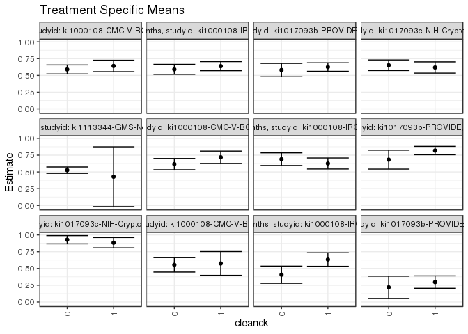

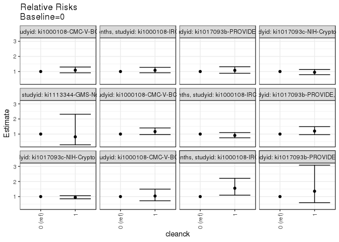

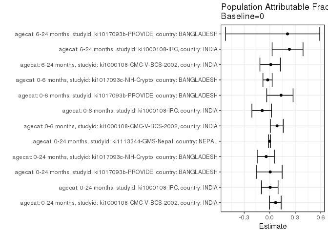

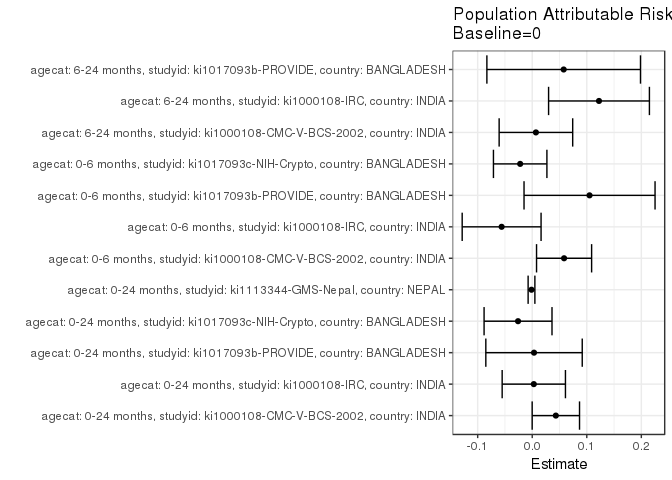

## Results Table

### Parameter: TSM

| agecat | studyid | country | intervention_level | baseline_level | estimate | ci_lower | ci_upper |
| --- | --- | --- | --- | --- | --- | --- | --- |
| 0-24 months | ki1000108-CMC-V-BCS-2002 | INDIA | 0 | NA | 0.5886026 | 0.5215070 | 0.6556982 |
| 0-24 months | ki1000108-CMC-V-BCS-2002 | INDIA | 1 | NA | 0.6406898 | 0.5552976 | 0.7260821 |
| 0-24 months | ki1000108-IRC | INDIA | 0 | NA | 0.5898056 | 0.5151020 | 0.6645093 |
| 0-24 months | ki1000108-IRC | INDIA | 1 | NA | 0.6375146 | 0.5696229 | 0.7054063 |
| 0-24 months | ki1017093b-PROVIDE | BANGLADESH | 0 | NA | 0.5797578 | 0.4800569 | 0.6794588 |
| 0-24 months | ki1017093b-PROVIDE | BANGLADESH | 1 | NA | 0.6244304 | 0.5607847 | 0.6880761 |
| 0-24 months | ki1017093c-NIH-Crypto | BANGLADESH | 0 | NA | 0.6510096 | 0.5717215 | 0.7302976 |
| 0-24 months | ki1017093c-NIH-Crypto | BANGLADESH | 1 | NA | 0.6176329 | 0.5336723 | 0.7015934 |
| 0-24 months | ki1113344-GMS-Nepal | NEPAL | 0 | NA | 0.5258964 | 0.4784121 | 0.5733807 |
| 0-24 months | ki1113344-GMS-Nepal | NEPAL | 1 | NA | 0.4285714 | -0.0170220 | 0.8741648 |
| 0-6 months | ki1000108-CMC-V-BCS-2002 | INDIA | 0 | NA | 0.6164911 | 0.5325282 | 0.7004539 |
| 0-6 months | ki1000108-CMC-V-BCS-2002 | INDIA | 1 | NA | 0.7184333 | 0.6265703 | 0.8102964 |
| 0-6 months | ki1000108-IRC | INDIA | 0 | NA | 0.6897253 | 0.5953349 | 0.7841158 |
| 0-6 months | ki1000108-IRC | INDIA | 1 | NA | 0.6257389 | 0.5435854 | 0.7078923 |
| 0-6 months | ki1017093b-PROVIDE | BANGLADESH | 0 | NA | 0.6829781 | 0.5422124 | 0.8237438 |
| 0-6 months | ki1017093b-PROVIDE | BANGLADESH | 1 | NA | 0.8181717 | 0.7555814 | 0.8807621 |
| 0-6 months | ki1017093c-NIH-Crypto | BANGLADESH | 0 | NA | 0.9285714 | 0.8672033 | 0.9899396 |
| 0-6 months | ki1017093c-NIH-Crypto | BANGLADESH | 1 | NA | 0.8840580 | 0.8071326 | 0.9609833 |
| 6-24 months | ki1000108-CMC-V-BCS-2002 | INDIA | 0 | NA | 0.5542169 | 0.4466172 | 0.6618165 |
| 6-24 months | ki1000108-CMC-V-BCS-2002 | INDIA | 1 | NA | 0.5750000 | 0.3977365 | 0.7522635 |
| 6-24 months | ki1000108-IRC | INDIA | 0 | NA | 0.4073976 | 0.2790130 | 0.5357822 |
| 6-24 months | ki1000108-IRC | INDIA | 1 | NA | 0.6335929 | 0.5327772 | 0.7344086 |
| 6-24 months | ki1017093b-PROVIDE | BANGLADESH | 0 | NA | 0.2187500 | 0.0526770 | 0.3848230 |
| 6-24 months | ki1017093b-PROVIDE | BANGLADESH | 1 | NA | 0.2967033 | 0.2039707 | 0.3894359 |

### Parameter: E(Y)

| agecat | studyid | country | intervention_level | baseline_level | estimate | ci_lower | ci_upper |
| --- | --- | --- | --- | --- | --- | --- | --- |
| 0-24 months | ki1000108-CMC-V-BCS-2002 | INDIA | NA | NA | 0.6319018 | 0.5759256 | 0.6878781 |
| 0-24 months | ki1000108-IRC | INDIA | NA | NA | 0.5926893 | 0.5398764 | 0.6455022 |
| 0-24 months | ki1017093b-PROVIDE | BANGLADESH | NA | NA | 0.5830619 | 0.5262762 | 0.6398476 |
| 0-24 months | ki1017093c-NIH-Crypto | BANGLADESH | NA | NA | 0.6250000 | 0.5603522 | 0.6896478 |
| 0-24 months | ki1113344-GMS-Nepal | NEPAL | NA | NA | 0.5245580 | 0.4773278 | 0.5717881 |
| 0-6 months | ki1000108-CMC-V-BCS-2002 | INDIA | NA | NA | 0.6748768 | 0.6092233 | 0.7405304 |
| 0-6 months | ki1000108-IRC | INDIA | NA | NA | 0.6336207 | 0.5704020 | 0.6968394 |
| 0-6 months | ki1017093b-PROVIDE | BANGLADESH | NA | NA | 0.7880435 | 0.7295878 | 0.8464992 |
| 0-6 months | ki1017093c-NIH-Crypto | BANGLADESH | NA | NA | 0.9064748 | 0.8572209 | 0.9557287 |
| 6-24 months | ki1000108-CMC-V-BCS-2002 | INDIA | NA | NA | 0.5609756 | 0.4682842 | 0.6536670 |
| 6-24 months | ki1000108-IRC | INDIA | NA | NA | 0.5298013 | 0.4450066 | 0.6145960 |
| 6-24 months | ki1017093b-PROVIDE | BANGLADESH | NA | NA | 0.2764228 | 0.1950773 | 0.3577682 |

### Parameter: RR

| agecat | studyid | country | intervention_level | baseline_level | estimate | ci_lower | ci_upper |
| --- | --- | --- | --- | --- | --- | --- | --- |
| 0-24 months | ki1000108-CMC-V-BCS-2002 | INDIA | 0 | 0 | 1.0000000 | 1.0000000 | 1.000000 |
| 0-24 months | ki1000108-CMC-V-BCS-2002 | INDIA | 1 | 0 | 1.0884930 | 0.9133901 | 1.297164 |
| 0-24 months | ki1000108-IRC | INDIA | 0 | 0 | 1.0000000 | 1.0000000 | 1.000000 |
| 0-24 months | ki1000108-IRC | INDIA | 1 | 0 | 1.0808893 | 0.9157240 | 1.275845 |
| 0-24 months | ki1017093b-PROVIDE | BANGLADESH | 0 | 0 | 1.0000000 | 1.0000000 | 1.000000 |
| 0-24 months | ki1017093b-PROVIDE | BANGLADESH | 1 | 0 | 1.0770539 | 0.8820959 | 1.315101 |
| 0-24 months | ki1017093c-NIH-Crypto | BANGLADESH | 0 | 0 | 1.0000000 | 1.0000000 | 1.000000 |
| 0-24 months | ki1017093c-NIH-Crypto | BANGLADESH | 1 | 0 | 0.9487308 | 0.7915338 | 1.137147 |
| 0-24 months | ki1113344-GMS-Nepal | NEPAL | 0 | 0 | 1.0000000 | 1.0000000 | 1.000000 |
| 0-24 months | ki1113344-GMS-Nepal | NEPAL | 1 | 0 | 0.8149351 | 0.2870102 | 2.313922 |
| 0-6 months | ki1000108-CMC-V-BCS-2002 | INDIA | 0 | 0 | 1.0000000 | 1.0000000 | 1.000000 |
| 0-6 months | ki1000108-CMC-V-BCS-2002 | INDIA | 1 | 0 | 1.1653589 | 0.9670005 | 1.404406 |
| 0-6 months | ki1000108-IRC | INDIA | 0 | 0 | 1.0000000 | 1.0000000 | 1.000000 |
| 0-6 months | ki1000108-IRC | INDIA | 1 | 0 | 0.9072291 | 0.7502880 | 1.096998 |
| 0-6 months | ki1017093b-PROVIDE | BANGLADESH | 0 | 0 | 1.0000000 | 1.0000000 | 1.000000 |
| 0-6 months | ki1017093b-PROVIDE | BANGLADESH | 1 | 0 | 1.1979472 | 0.9615208 | 1.492508 |
| 0-6 months | ki1017093c-NIH-Crypto | BANGLADESH | 0 | 0 | 1.0000000 | 1.0000000 | 1.000000 |
| 0-6 months | ki1017093c-NIH-Crypto | BANGLADESH | 1 | 0 | 0.9520624 | 0.8535159 | 1.061987 |
| 6-24 months | ki1000108-CMC-V-BCS-2002 | INDIA | 0 | 0 | 1.0000000 | 1.0000000 | 1.000000 |
| 6-24 months | ki1000108-CMC-V-BCS-2002 | INDIA | 1 | 0 | 1.0375000 | 0.7207649 | 1.493422 |
| 6-24 months | ki1000108-IRC | INDIA | 0 | 0 | 1.0000000 | 1.0000000 | 1.000000 |
| 6-24 months | ki1000108-IRC | INDIA | 1 | 0 | 1.5552199 | 1.0935145 | 2.211867 |
| 6-24 months | ki1017093b-PROVIDE | BANGLADESH | 0 | 0 | 1.0000000 | 1.0000000 | 1.000000 |
| 6-24 months | ki1017093b-PROVIDE | BANGLADESH | 1 | 0 | 1.3563579 | 0.5967648 | 3.082801 |

### Parameter: PAR

| agecat | studyid | country | intervention_level | baseline_level | estimate | ci_lower | ci_upper |
| --- | --- | --- | --- | --- | --- | --- | --- |
| 0-24 months | ki1000108-CMC-V-BCS-2002 | INDIA | 0 | NA | 0.0432993 | -0.0001129 | 0.0867114 |
| 0-24 months | ki1000108-IRC | INDIA | 0 | NA | 0.0028837 | -0.0551258 | 0.0608932 |
| 0-24 months | ki1017093b-PROVIDE | BANGLADESH | 0 | NA | 0.0033040 | -0.0850714 | 0.0916794 |
| 0-24 months | ki1017093c-NIH-Crypto | BANGLADESH | 0 | NA | -0.0260096 | -0.0882660 | 0.0362468 |
| 0-24 months | ki1113344-GMS-Nepal | NEPAL | 0 | NA | -0.0013385 | -0.0075315 | 0.0048546 |
| 0-6 months | ki1000108-CMC-V-BCS-2002 | INDIA | 0 | NA | 0.0583858 | 0.0079086 | 0.1088630 |
| 0-6 months | ki1000108-IRC | INDIA | 0 | NA | -0.0561046 | -0.1284190 | 0.0162098 |
| 0-6 months | ki1017093b-PROVIDE | BANGLADESH | 0 | NA | 0.1050654 | -0.0150278 | 0.2251585 |
| 0-6 months | ki1017093c-NIH-Crypto | BANGLADESH | 0 | NA | -0.0220966 | -0.0711015 | 0.0269082 |
| 6-24 months | ki1000108-CMC-V-BCS-2002 | INDIA | 0 | NA | 0.0067587 | -0.0606583 | 0.0741758 |
| 6-24 months | ki1000108-IRC | INDIA | 0 | NA | 0.1224037 | 0.0299825 | 0.2148249 |
| 6-24 months | ki1017093b-PROVIDE | BANGLADESH | 0 | NA | 0.0576728 | -0.0831375 | 0.1984830 |

### Parameter: PAF

| agecat | studyid | country | intervention_level | baseline_level | estimate | ci_lower | ci_upper |
| --- | --- | --- | --- | --- | --- | --- | --- |
| 0-24 months | ki1000108-CMC-V-BCS-2002 | INDIA | 0 | NA | 0.0685221 | -0.0023693 | 0.1343998 |
| 0-24 months | ki1000108-IRC | INDIA | 0 | NA | 0.0048654 | -0.0979409 | 0.0980453 |
| 0-24 months | ki1017093b-PROVIDE | BANGLADESH | 0 | NA | 0.0056667 | -0.1579980 | 0.1462000 |
| 0-24 months | ki1017093c-NIH-Crypto | BANGLADESH | 0 | NA | -0.0416153 | -0.1472817 | 0.0543190 |
| 0-24 months | ki1113344-GMS-Nepal | NEPAL | 0 | NA | -0.0025516 | -0.0144355 | 0.0091931 |
| 0-6 months | ki1000108-CMC-V-BCS-2002 | INDIA | 0 | NA | 0.0865132 | 0.0077969 | 0.1589846 |
| 0-6 months | ki1000108-IRC | INDIA | 0 | NA | -0.0885461 | -0.2095900 | 0.0203850 |
| 0-6 months | ki1017093b-PROVIDE | BANGLADESH | 0 | NA | 0.1333243 | -0.0353215 | 0.2744990 |
| 0-6 months | ki1017093c-NIH-Crypto | BANGLADESH | 0 | NA | -0.0243764 | -0.0802125 | 0.0285735 |
| 6-24 months | ki1000108-CMC-V-BCS-2002 | INDIA | 0 | NA | 0.0120482 | -0.1154830 | 0.1249990 |
| 6-24 months | ki1000108-IRC | INDIA | 0 | NA | 0.2310370 | 0.0281675 | 0.3915575 |
| 6-24 months | ki1017093b-PROVIDE | BANGLADESH | 0 | NA | 0.2086397 | -0.5191762 | 0.5877693 |